```python
import numpy as np, pandas as pd, scipy.stats, sympy, matplotlib.pyplot as plt,matplotlib as mpl, math
from numpy import random_intel # Used to speed up deneration (~x10)
plt.rc('font', family='serif')
plt.rc('text', usetex=True)
mpl.rcParams['figure.dpi'] = 150
mpl.rcParams['savefig.dpi'] = 300
from IPython.display import display
from math import factorial
from sympy import integrate,Symbol,exp,Integral
from sympy.abc import x;from sympy import init_printing;init_printing()
```

# Exercise 6: Markov Chain Monte Carlo simulation

- The number of busy lines in a trunk group (Erlang system) is given by a truncated Poisson distribution \begin{equation} B = P(n) = \frac{\frac{A^n}{n!}}{\sum_{i=0}^n\frac{A^i}{i!}} \end{equation}
- Generate values from this distribution by applying the Metropolis-Hastings algorithm, verify with a χ2-test. You can use the parameter values from exercise 4.
- For two different call types the joint number of occupied lines is given by $$ P ( i , j ) = \frac{1}{K}\frac{A_1^i}{i!}\frac{A_2^j}{j!}$$
- Use Metropolis-Hastings, directly and coordinate wise to generate variates from this distribution. You can use $A_1$, $A_2$ = 4 og n = 10.
- Test the distribution with a χ2 test
- Optional: Redo the coordinate wise solution using Gibbs sampling. You will need to find the conditional distributions analytically.
- Optional: Redo the exercise with BUGS or other available software
- The system can be extended to an arbitrary dimension, and we can add restrictions on the different call types.

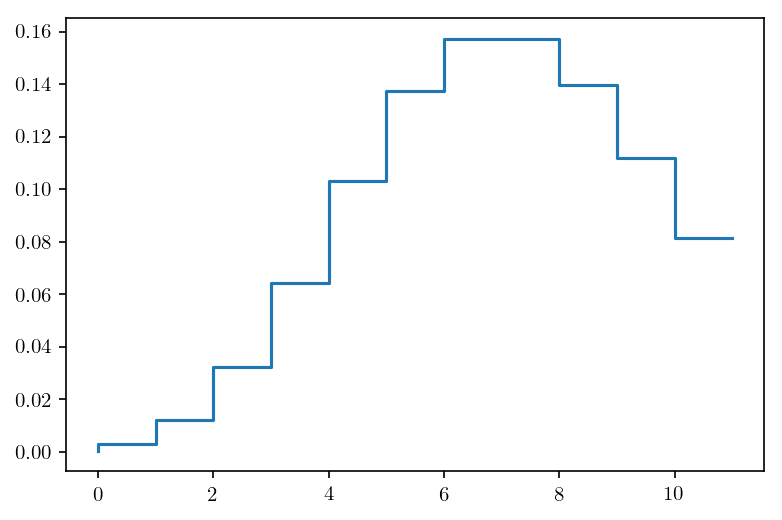

```python
l = 1
s = 8
n = 11
i = np.array(list(range(n+1)))
H = np.ones((n+1,n+1))/(n+1)
A = l * s

result = A**i/[factorial(j)  for j in i]
res = result/result.sum()
_ = plt.step(i,res)
```

```python
H
```

[output not shown]

### Metropolis-Hastings algorithm

- Proposal distribution $h(x, y)$
- Acceptance of solution? The solution will be accepted with probability $$ min \left(1, \frac{f (y)h(y, x)}{f (x)h(x, y)}\right)=min \left(1, \frac{g (y)h(y, x)}{g (x)h(x, y)}\right)$$
- Avoiding the troublesome constant $K!$
- Frequently we apply a symmetric proposal distribution $h(y, x) = h(y, x)$ Metropolis algorithm
- It can be shown that this Markov chain will have $f(x)$ as stationary distribution.